**Archived copy.** This is the landing page participants reached from the simulation 3 email, saved as static HTML for the public dataset. The institution's name, logo and domain are replaced by *[anonymized …]*, details the platform filled in for each participant appear as *[bracketed placeholders]*. The page makes no network requests.

# Phishing Awareness Training

Dear [recipient's first name],

This email was a simulated phishing attempt. Don't be discouraged—this can happen to all of us. Instead, let’s take a look at why this happened and how you can learn from it.

## How you could have identified this phishing e-mail

From:

To: [recipient's name]

Subject: New user sign-on notification

Please to review your recent activity

Acceptable Use Policy

This message was sent to: "[recipient's email address]"

### The four highlighted cues

1. **Suspicious sender address** – Check if the email address matches the official domain of the sender. For instance, an email from a colleague at [anonymized institution] should originate from an **@[anonymized domain]** address.
2. **No personal greeting** – Generic salutations instead of your real name can indicate phishing.
3. **Threatening with negative consequences** – Threatening with negative consequences if not acting urgently - Online scams often try to make you feel like you need to do something right away. Whenever this happens, stop and first verify with someone else you know whether this is a legitimate, urgent action you need to take.
4. **Misleading hyperlinks** – Do not click on links blindly. A link labeled *"Click here"* could lead to a fraudulent website. Always double-check the destination by hovering over the link and checking the URL in the bottom left corner of your browser.

**First Indicators to Watch Out For**

- **Check the communication channel** - Personal or other sensitive information should never be requested via email.

  **Example:** [anonymized institution] will never ask for personal or sensitive details via email. If you need to reset your password, you will receive a notification from the official [anonymized institution] IT email address, which looks like:

  **From:** [anonymized institution] Password Management System <password-management-system@[anonymized domain]>  
  **Sent:** Sunday, February 9, 2025 3:18 AM  
  **To:**  
  **Subject:** Main [anonymized institution] password expiry warning

  The password for your user ID [user ID] is due to expire in 30 days and should be changed as soon as possible.

  To change your password please go to the [anonymized institution] password management service:  
  https://[anonymized domain]/  
  (We suggest that you copy or type this address into your browser rather than clicking on it).

  If you have not registered your mobile phone number and/or your personal email address with the password management service you will be asked to do so before you can change your password.

  If your password is not changed within the next 30 days, it will expire.

  If you have registered a current mobile phone number and/or personal email address, you can reset an expired or forgotten password at:  
  https://[anonymized domain]/

  If you have not registered a phone or email address before your password expires you will need to contact the IT Services Help Desk.

  Please note:

  1. This message ONLY applies to this user ID [user ID] and not any other user IDs you may own.  
  2. [anonymized IT department] will NEVER ask you to quote your password.  
  3. Passwords CANNOT be given out over the phone.

  [anonymized institution]'s Information Security Policy requires that passwords are changed on a regular basis. Your [anonymized institution] user ID and password are used to access all central IT services.

  For further help please contact the IT Services Help Desk (servicedesk@[anonymized domain]).
- **Persuasion tactics** - Scammers often pose as authorities or a reputable source to request something from you.

  **Example:** A fake email from your "IT department" asks you to provide login details to fix an urgent security issue.
- **Extreme consequences** - Be wary of emails that promise extravagant rewards, severe penalties or unsolicited requests.

  **Example:** "You have won a free vacation! Click here to claim your prize!" or "Your account will be permanently disabled unless you act now!"

**What to Do Next Time**

Whenever an email asks you to take action (e.g., downloading an attachment, clicking on a link, updating information, transferring money, etc.), follow these steps:

- **Check the URL** - Compare the link in the phishing email to the official website's URL.

  **Example:** If an email claims to be from PayPal but the link directs to *"paypaal.com"* instead of *"paypal.com"*, it is a phishing attempt. Always verify links before clicking.
- **Look for hidden hyperlinks** - Ensure displayed URLs match the real ones.

  **Example:** A hyperlink may say "www.yourbank.com," but when hovered over, it actually links to "www.your-bank.com".
- **Check the return-path** - The metadata often reveals inconsistencies.

  **Steps:**
  1. Click on the three dots in the upper right corner of the email.
  2. Select "View" → "View message details".
  3. Look for the "Return-Path" field, which shows the actual email address where a reply would be sent.

  **Example:** An email claiming to be from "support@amazon.com" but with a return-path of "randomuser@gmail.com" is suspicious.

**If You're Still Unsure**

- **Consult a colleague** - If something feels off, ask a coworker before taking action.
- **Report to IT** - Your IT department can verify if an email is legitimate.
  - There is a button in outlook to report phishing:

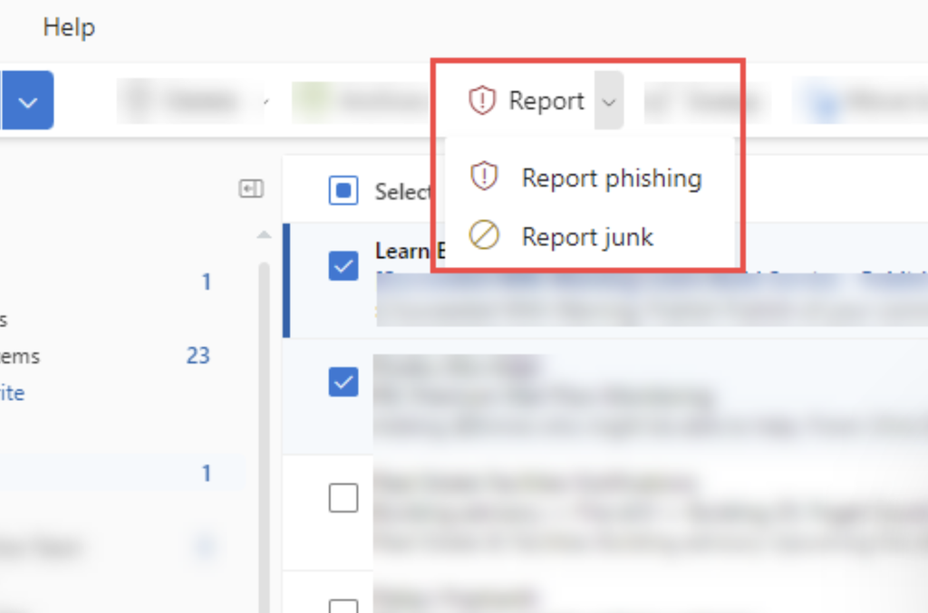

  - Or forward the email to phish@[anonymized domain]

**Clicking the Link is Not Game Over**

The phishing campaign has two stages. It requires the submission of a username & password to get to the information page. This page is hosted on a non-Microsoft domain, www.bankmenia.fr, which is the biggest hint that the webpage is trying to phish you.

### Use this phishing simulation as a learning opportunity and make sure to check for phishing indicators next time!